# 5. Vector Autoregressions: A Primer

Jaromir Baxa

2022-09-07

#### Outline:

I. VAR model for the United States, 1960 - 2008  
II. Generating nice graphical output with R  
III. Sample sensitivity of the impulse responses  
IV. Predictions for 2022 based on VAR model

```r
rm(list=ls())

library(xts)
```

```r
library(pdfetch) #Library for loading FRED data
library(ggplot2) #Library for plotting
library(mFilter) #Library for HP filter
library(tsbox)   #Library for time series conversion
library(forecast)#Library for simple plotting
```

Loading some data from FRED

```r
data_var <- pdfetch_FRED(c("GDP", "GDPC1", "GDPPOT", "FEDFUNDS", "CPIAUCSL", "PPIACO", "UNRATE", "M2SL", "GS10"))
data_var <- to.period(data_var, period = "quarter", OHLC = FALSE)
data_var <- ts_first_of_period(data_var) #to assure consistency in dates across time series objects
View(data_var)
```

```r
data_var$lgdp <- log(data_var$GDPC1) # Log of real GDP
data_var$lgdp_pot <- log(data_var$GDPPOT) # Log of potential GDP
data_var$gdpgap <- 100*(data_var$lgdp - data_var$lgdp_pot) # Gap as a difference between actual and potential output
hp_gdp <- hpfilter(data_var$lgdp, freq = 1600, type="lambda")
data_var$gdpgap_hp <- 100*hp_gdp$cycle
data_var$d_lgdp <- 100*diff(data_var$lgdp,1) #first differences
data_var$gdp_growth <- 100*diff(data_var$lgdp,4) #seasonal difference (annual growth), in percent

data_var$l_cpi <- log(data_var$CPIAUCSL)
data_var$inflation <- 100*diff(data_var$l_cpi, 4) #inflation as y-o-y change in CPI, in percent
#data_var$infrate <- 1/4*(data_var$inflation + lag(data_var$inflation, k=1) + lag(data_var$inflation, k=2) + lag(data_var$inflation, k=3))

data_var$l_ppiaco <- log(data_var$PPIACO)
data_var$ppiaco_ld <- 100*diff(data_var$l_ppiaco,4)

data_var$unrate <- data_var$UNRATE
data_var$fedfunds <- data_var$FEDFUNDS
data_var$gs10 <- data_var$GS10

data_var$m2 <- data_var$M2SL
data_var$m2_l <- log(data_var$m2)
data_var$m2_ld <- 100*diff(data_var$m2_l,4)
```

#### I. VAR model: Pre Great Recession sample

```r
library(vars) #main library for VAR models in R
```

Selecting the data and setting the sample for estimation.

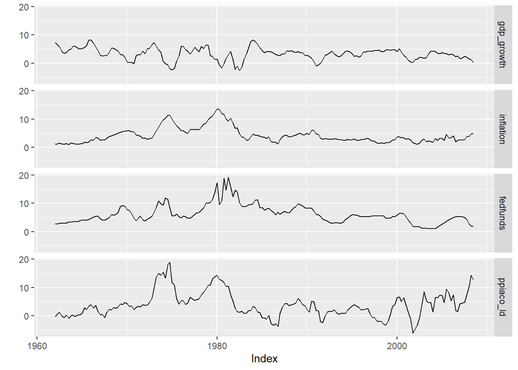

```r
data_6208 <- data_var["1962-01-01/2008-07-01"]
vardata1 <- data_6208[,c("gdp_growth", "inflation", "fedfunds", "ppiaco_ld")]
autoplot(vardata1) #simple plot for a brief check of the data, for outliers seasonality etc.
```

Lag length selection

```r
var1.select <- VARselect(vardata1, lag.max=6, type ="const")
var1.select$selection
```

```
## AIC(n)  HQ(n)  SC(n) FPE(n)
##      6      6      2      6
```

Estimation

```r
var1 <- VAR(vardata1, p=6, type = "const")
summary(var1)
```

```
##
## VAR Estimation Results:
## =========================
## Endogenous variables: gdp_growth, inflation, fedfunds, ppiaco_ld
## Deterministic variables: const
## Sample size: 181
## Log Likelihood: -873.175
## Roots of the characteristic polynomial:
## 0.9324 0.9324 0.8588 0.8588 0.8423 0.8423 0.8416 0.8416 0.8377 0.8377 0.8189 0.8189 0.8149 0.8149 0.8096 0.8096 0.7998 0.7998 0.6474 0.6474 0.5618 0.4821 0.4037 0.05717
## Call:
## VAR(y = vardata1, p = 6, type = "const")
##
##
## Estimation results for equation gdp_growth:
## ===========================================
## gdp_growth = gdp_growth.l1 + inflation.l1 + fedfunds.l1 + ppiaco_ld.l1 + gdp_growth.l2 + inflation.l2 + fedfunds.l2 + ppiaco_ld.l2 + gdp_growth.l3 + inflation.l3 + fedfunds.l3 + ppiaco_ld.l3 + gdp_growth.l4 + inflation.l4 + fedfunds.l4 + ppiaco_ld.l4 + gdp_growth.l5 + inflation.l5 + fedfunds.l5 +…
##
##               Estimate Std. Error t value Pr(>|t|)
## gdp_growth.l1  0.96527    0.08314  11.610  < 2e-16 ***
## inflation.l1  -0.20311    0.16187  -1.255 0.211449
## fedfunds.l1    0.08444    0.05842   1.446 0.150317
## ppiaco_ld.l1   0.01274    0.05628   0.226 0.821203
## gdp_growth.l2  0.08134    0.11268   0.722 0.471475
## inflation.l2   0.00652    0.21919   0.030 0.976307
## fedfunds.l2   -0.25371    0.07094  -3.576 0.000464 ***
## ppiaco_ld.l2   0.02916    0.07569   0.385 0.700609
## gdp_growth.l3 -0.08595    0.10853  -0.792 0.429571
## inflation.l3  -0.02273    0.19791  -0.115 0.908695
## fedfunds.l3   -0.06651    0.07431  -0.895 0.372131
## ppiaco_ld.l3   0.05351    0.07121   0.751 0.453515
## gdp_growth.l4 -0.29907    0.10592  -2.823 0.005371 **
## inflation.l4   0.13101    0.19075   0.687 0.493214
## fedfunds.l4    0.01959    0.07646   0.256 0.798172
## ppiaco_ld.l4  -0.05667    0.06958  -0.814 0.416651
## gdp_growth.l5  0.22886    0.10974   2.086 0.038651 *
## inflation.l5   0.01299    0.20758   0.063 0.950179
## fedfunds.l5   -0.03454    0.07697  -0.449 0.654267
## ppiaco_ld.l5   0.04953    0.07401   0.669 0.504341
## gdp_growth.l6  0.07010    0.07666   0.914 0.361917
## inflation.l6   0.15720    0.15299   1.028 0.305755
```

[output cut: 128 more lines]

```
##
##
## Covariance matrix of residuals:
##            gdp_growth inflation fedfunds ppiaco_ld
## gdp_growth    0.67875    0.0222   0.4018   0.06749
## inflation     0.02220    0.3365   0.1833   0.70730
## fedfunds      0.40180    0.1833   1.3925   0.49403
## ppiaco_ld     0.06749    0.7073   0.4940   2.85161
##
## Correlation matrix of residuals:
##            gdp_growth inflation fedfunds ppiaco_ld
## gdp_growth    1.00000   0.04645   0.4133   0.04851
## inflation     0.04645   1.00000   0.2678   0.72206
## fedfunds      0.41330   0.26784   1.0000   0.24792
## ppiaco_ld     0.04851   0.72206   0.2479   1.00000
```

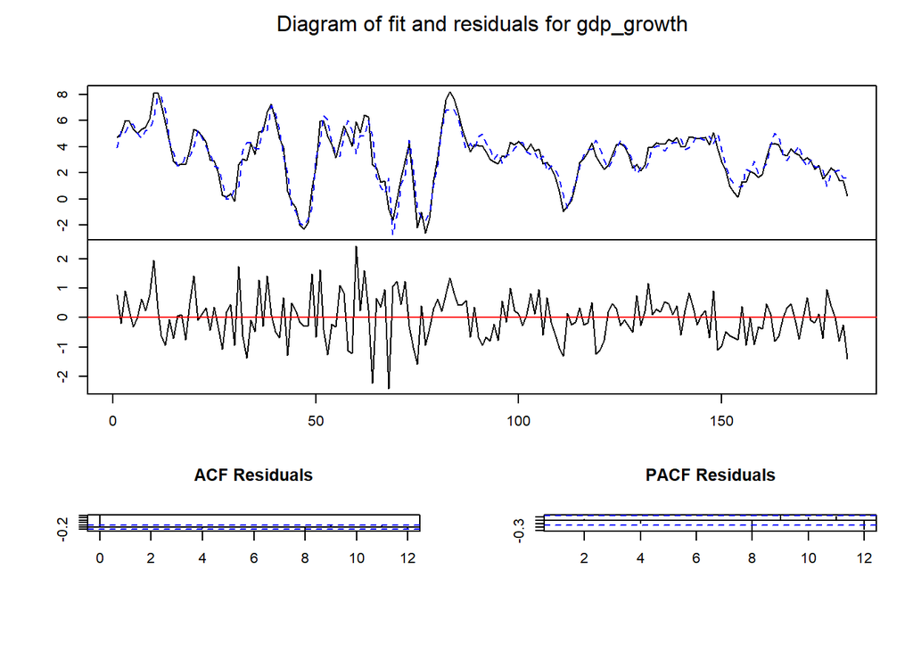

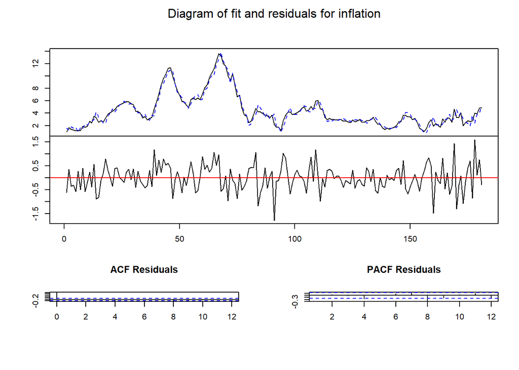

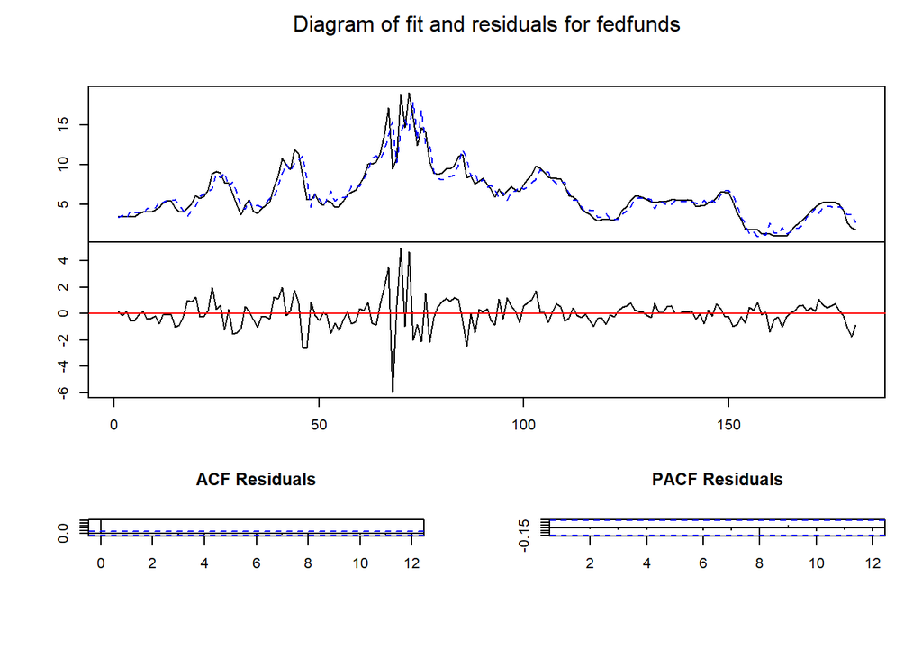

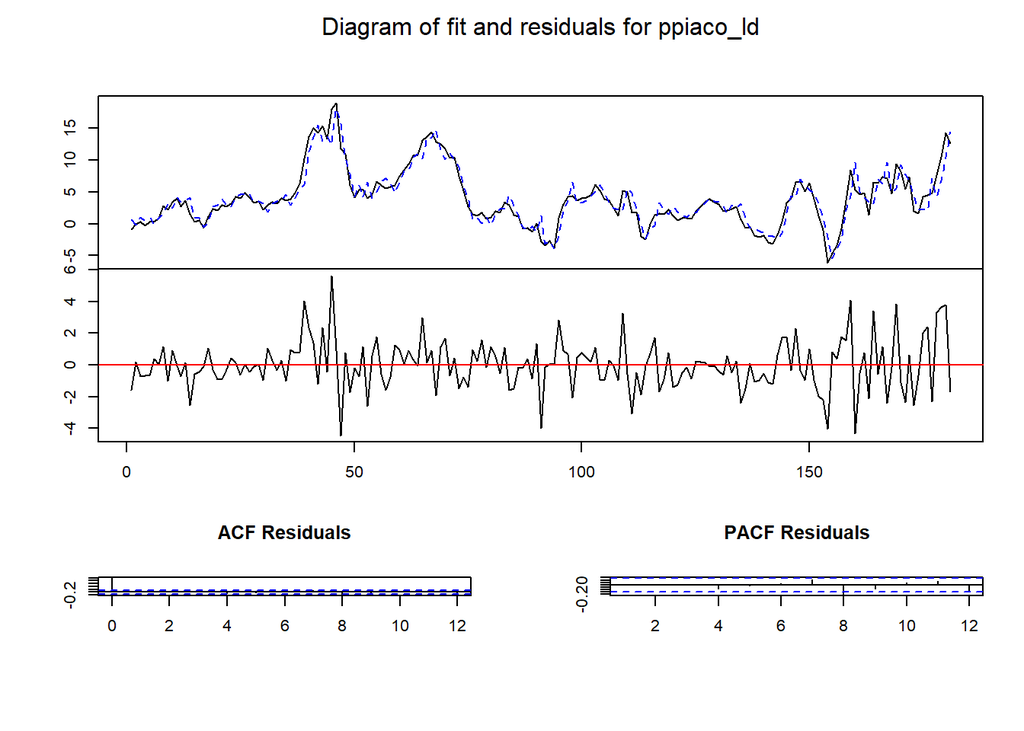

```r
plot(var1)
```

Forecasting

```r
predict(var1, n.ahead = 12, ci = 0.95)
```

```
## $gdp_growth
##           fcst      lower    upper       CI
##  [1,] 1.267230 -0.3475071 2.881967 1.614737
##  [2,] 2.520189  0.2135834 4.826794 2.306605
##  [3,] 3.619705  0.8244238 6.414987 2.795281
##  [4,] 4.684868  1.5114357 7.858299 3.173432
##  [5,] 4.475200  1.0640951 7.886305 3.411105
##  [6,] 4.053785  0.3121845 7.795385 3.741600
##  [7,] 3.584577 -0.3540401 7.523194 3.938617
##  [8,] 2.920274 -1.1554494 6.995997 4.075723
##  [9,] 2.908335 -1.2759149 7.092585 4.184250
## [10,] 2.939782 -1.3139079 7.193472 4.253690
## [11,] 2.833596 -1.4694804 7.136673 4.303077
## [12,] 2.930978 -1.3970896 7.259046 4.328068
##
```

[output cut: 44 more lines]

[figure not shown]

```r
plot(predict(var1))
```

[figure not shown]

```r
fanchart(predict(var1))
```

##### Impulse responses

Identification in this case = Cholesky-based i.e. Cholesky decomposition of residuals covariance matrix is used to generate IRF and FEVD.  
Consequences: based on ordering, each variables influences contemporaneously only those ordered after it.

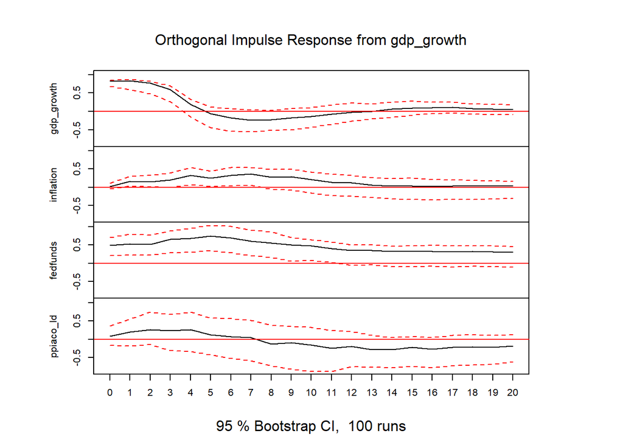

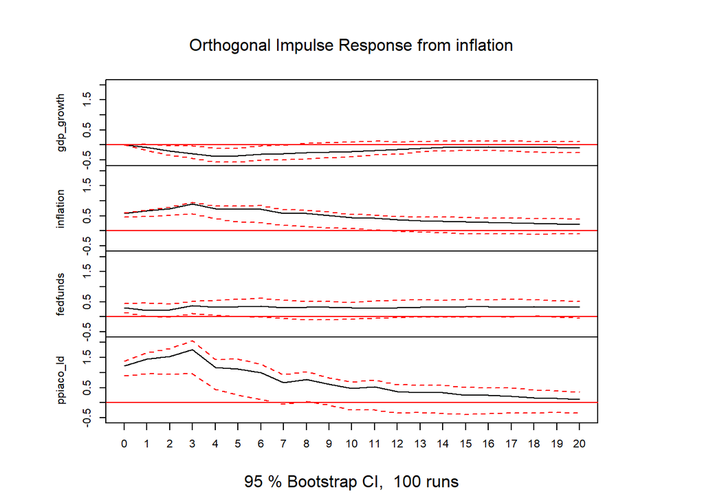

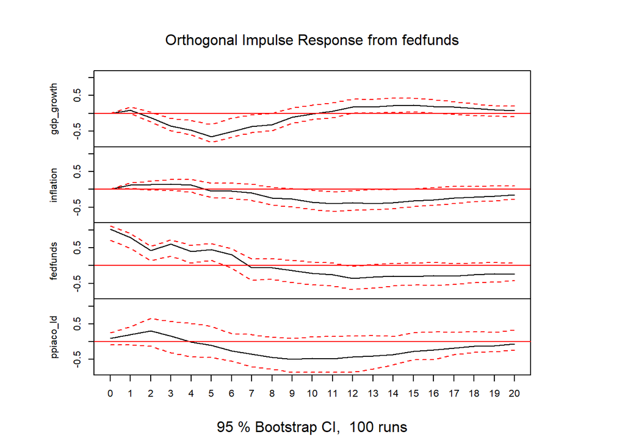

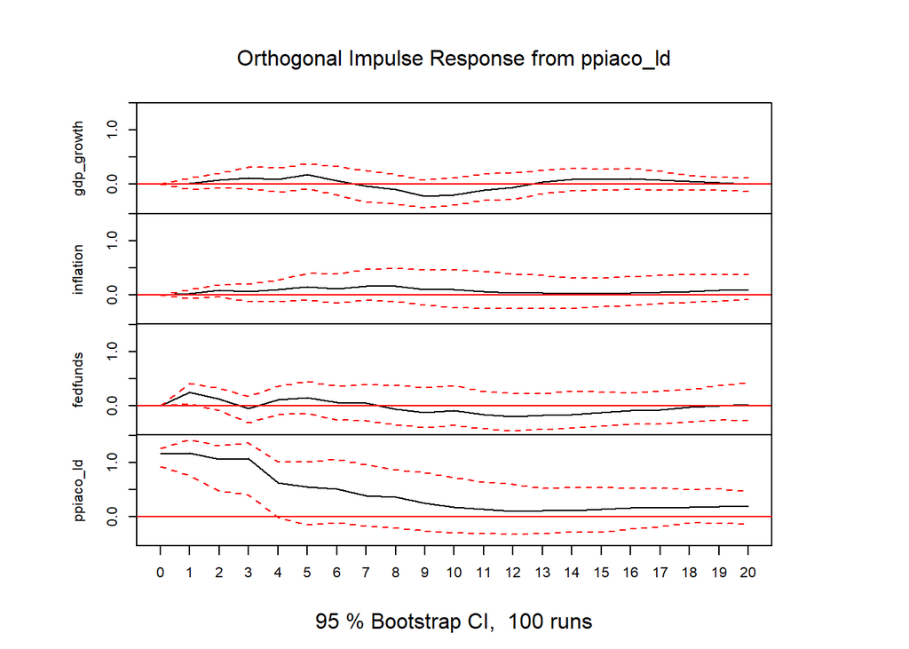

```r
nAhead <- 20
var1irf <- irf(var1, n.ahead = nAhead, ci = 0.95,
              cumulative = F, boot = T, ortho = T)
#default plots from vars package
plot(var1irf)
```

See responses in period 0 (= time of shock):

- gdp growth influences all other variables contemporaneously
- cpi contemporaneously influences all variables but gdp growth
- fedrate contemporaneously influences also commodity prices
- commodity price index has contemporary impact only on itself
- price puzzle is present

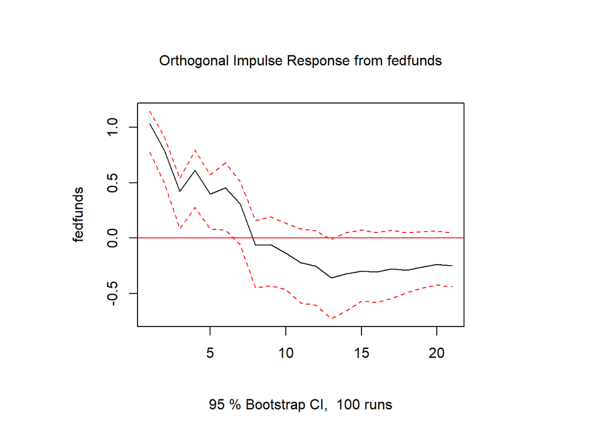

```r
plot(irf(var1,impulse = "fedfunds", response = "fedfunds", n.ahead = 20))
```

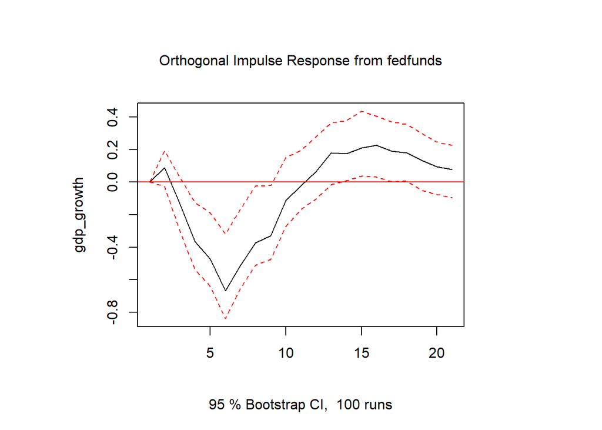

```r
plot(irf(var1,impulse = "fedfunds", response = "gdp_growth", n.ahead = 20))
```

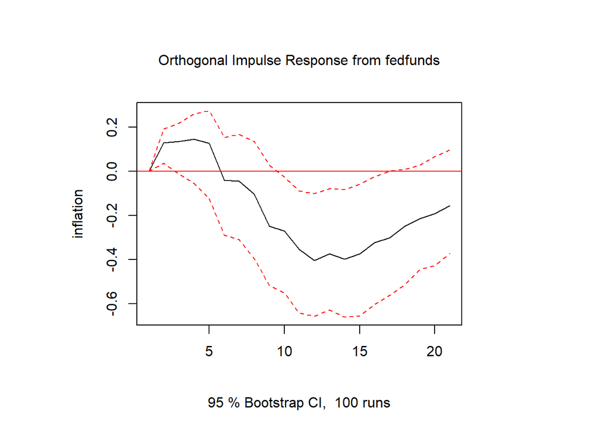

```r
plot(irf(var1,impulse = "fedfunds", response = "inflation", n.ahead = 20))
```

Forecast error variance decomposition:

[figure not shown]

```r
plot(fevd(var1))
```

Same thing by means of package svars:

```r
# install.packages("svars")

library(svars)
```

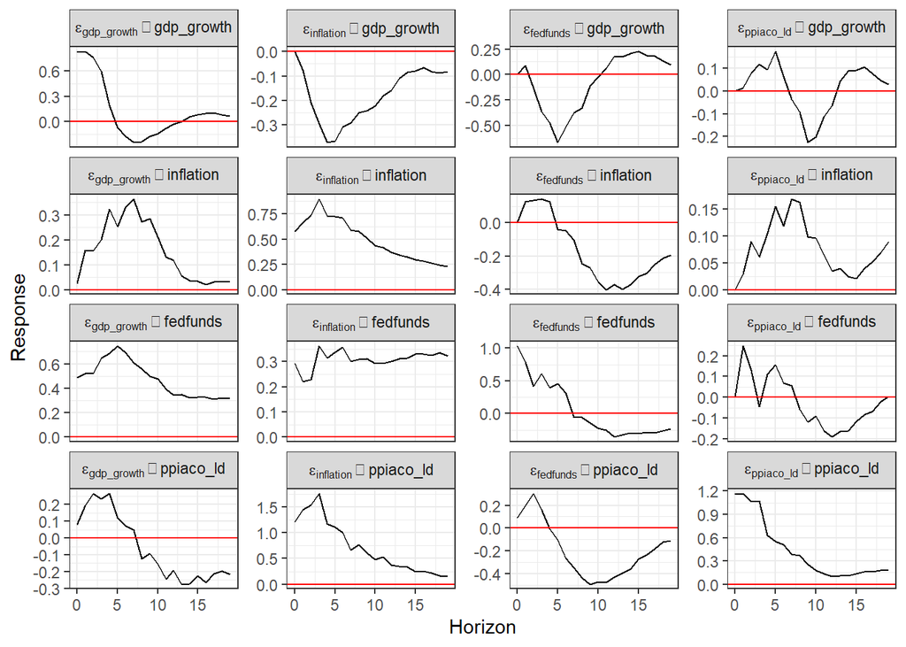

```r
var1_cholesky <- id.chol(var1)
var1_cholesky_svarsirf <- irf(var1_cholesky, n.ahead = 20)
plot(var1_cholesky_svarsirf)
```

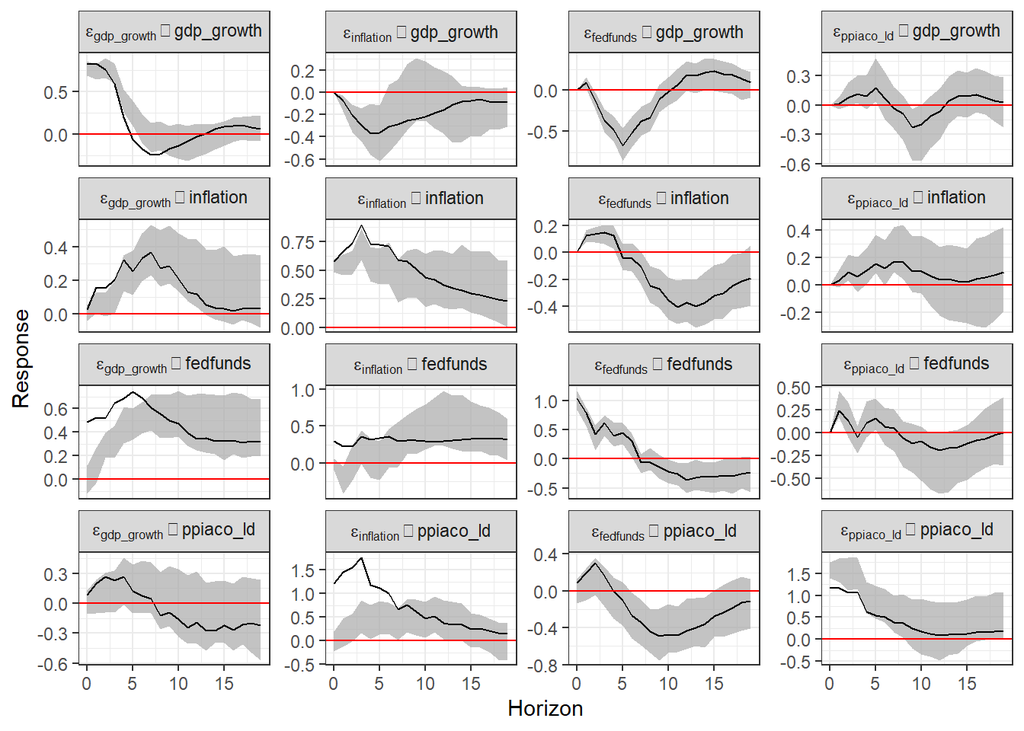

```r
var1_bootirf <- wild.boot(var1_cholesky, design = "fixed", distr = "gaussian", n.ahead = 20, nboot = 100)

plot(var1_bootirf) #1sd bands by default
```

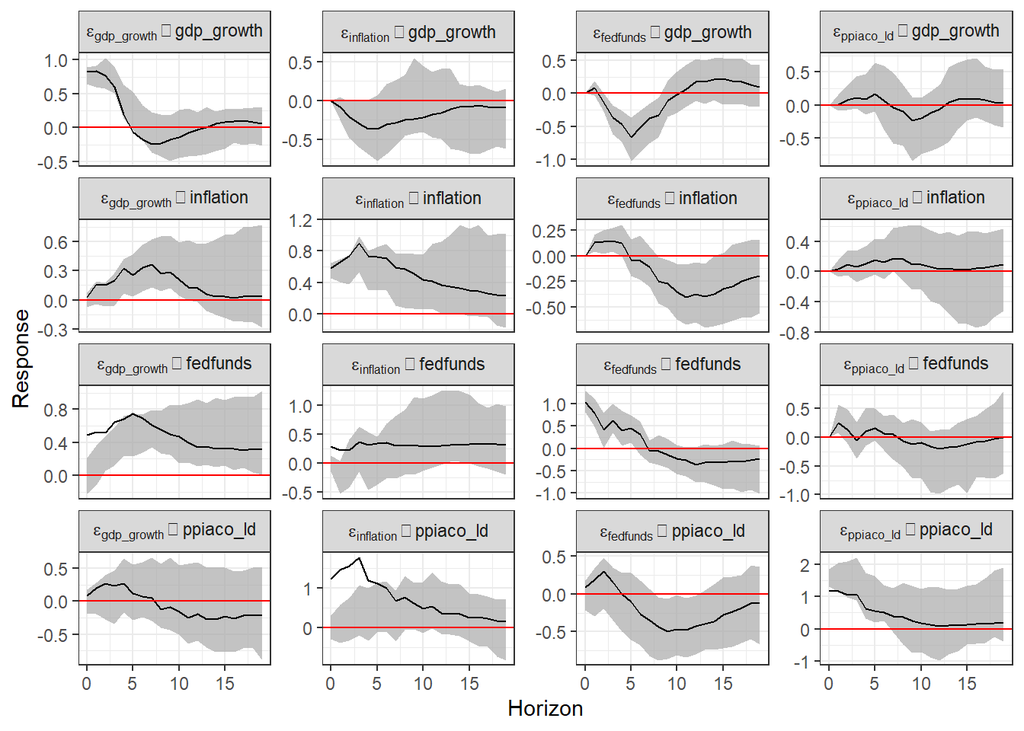

```r
plot(var1_bootirf, lowerq = 0.05, upperq = 0.95)
```

Historical decompositions (requires svars package, too)

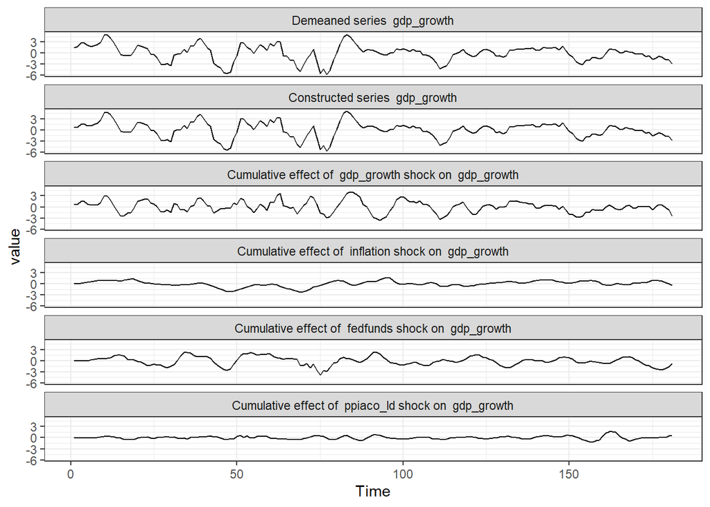

```r
var1_cholesky_hd <- hd(var1_cholesky, series = 1)
plot(var1_cholesky_hd) #not a nice bar plot one would expect
```

##### Custom impulse responses

###### Example 1

```r
#install.packages("remotes")
#remotes::install_github("sfeuerriegel/ResearchGroupTools")
library("ResearchGroupTools")
```

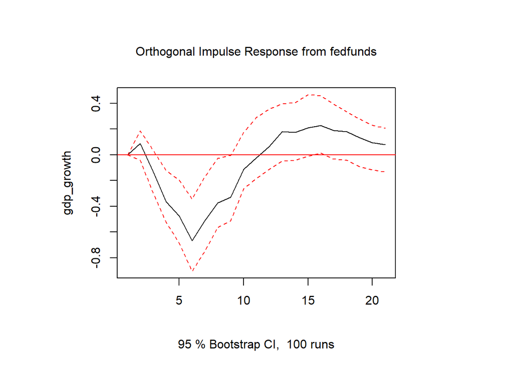

```r
var1irf_i_y <- irf(var1, impulse = "fedfunds", response = "gdp_growth",
                   n.ahead = nAhead, ci = 0.95,
                   cumulative = F, boot = T, ortho = T)
plot(var1irf_i_y)
```

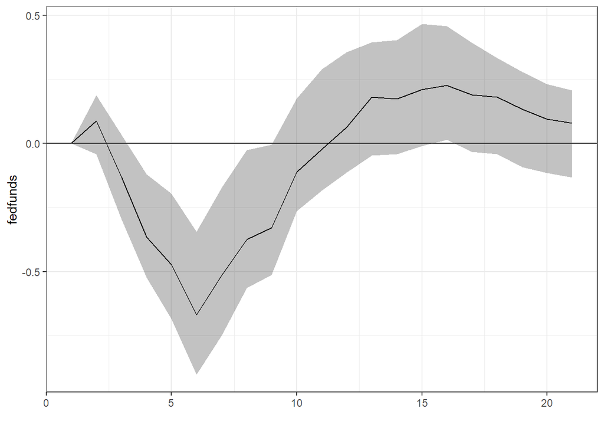

```r
plotIrf(var1irf_i_y)
```

###### Example 2

```r
library(ggplot2)
library(dplyr)
library(patchwork)
extract_varirf <- function(...){

  varirf_object <- list(...) #list one or more varirf input objects

  get_vec_length <- function(list_item){nrow(list_item[[1]][[1]])}

  if (!("varirf" %in% mapply(class, varirf_object))){
    stop("this function only accepts 'varirf' class objects")
  }

  if (length(unique(mapply(class, varirf_object)))!=1){
    stop("all input items must be 'varirf' class objects")
  }
  if (length(unique(mapply(get_vec_length, varirf_object)))!=1){
    stop("all irf vectors must have the same length")
  }

  period <- as.data.frame(0:(nrow(varirf_object[[1]][[1]][[1]])-1))
  names(period) <- "period"

  for (l in 1:length(varirf_object)){
    for (i in 1:3){
      for (j in 1:dim(varirf_object[[l]][[i]][[1]])[2]){
        for (k in 1:length(varirf_object[[l]][[1]])){
          temp_colname <- paste(names(varirf_object[[l]][i]), #vector type (irf, lower, or upper)
                                names(varirf_object[[l]][[i]])[k], #impulse name
                                colnames(varirf_object[[l]][[i]][[k]])[j], #response name
                                sep = "_")

          temp <- as.data.frame(varirf_object[[l]][[i]][[k]][, j]) #extracts the vector

          names(temp) <- temp_colname #add the column name (vectortype_impulse_reponse)
          period <- cbind(period, temp)
        }

      }
    }
  }
  names(period) <- tolower(names(period))
  return(period)
}
# source: https://raw.githubusercontent.com/anguyen1210/var-tools/master/R/extract_varirf.R
```

```r
multiple_varirf_var <- extract_varirf(var1irf)
head(multiple_varirf_var)
```

```
##   period irf_gdp_growth_gdp_growth irf_inflation_gdp_growth
## 1      0                0.82386048               0.00000000
## 2      1                0.83199800              -0.07738519
## 3      2                0.76341273              -0.20739100
## 4      3                0.59513977              -0.29433969
## 5      4                0.19244938              -0.37130309
## 6      5               -0.06920011              -0.36609116
##   irf_fedfunds_gdp_growth irf_ppiaco_ld_gdp_growth irf_gdp_growth_inflation
## 1              0.00000000               0.00000000               0.02694215
## 2              0.08846898               0.01483409               0.15811086
## 3             -0.13085642               0.07799306               0.15498104
## 4             -0.36485142               0.11667116               0.20287589
## 5             -0.47310918               0.09302381               0.32345368
## 6             -0.66811961               0.17372259               0.25235472
##   irf_inflation_inflation irf_fedfunds_inflation irf_ppiaco_ld_inflation
```

[output cut: 111 more lines]

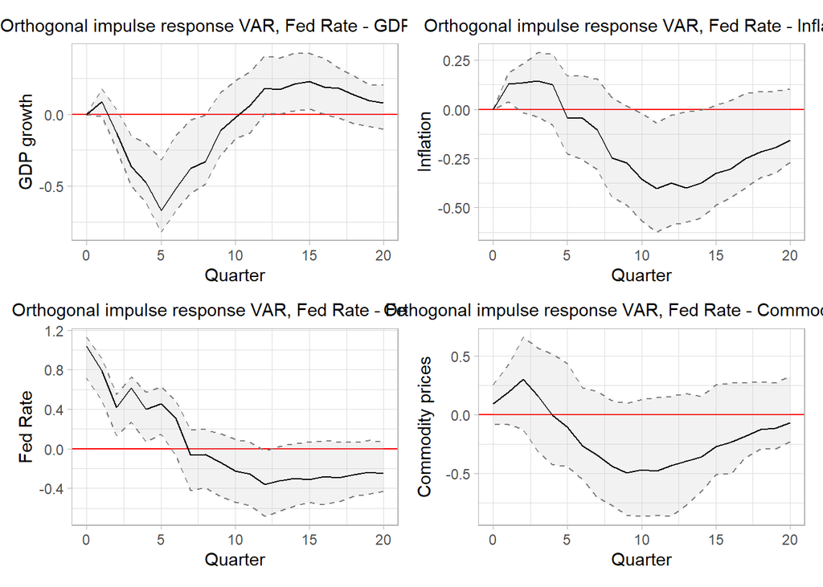

```r
i_y_var <- multiple_varirf_var %>%
  ggplot(aes(x=period, y=irf_fedfunds_gdp_growth, ymin=lower_fedfunds_gdp_growth, ymax=upper_fedfunds_gdp_growth)) +
  geom_hline(yintercept = 0, color="red") +
  geom_ribbon(fill="grey", alpha=.2, color="grey50", linetype="dashed") +
  geom_line() +
  theme_light() +
  ggtitle("Orthogonal impulse response VAR, Fed Rate - GDP growth")+
  ylab("GDP growth")+
  xlab("Quarter") +
  theme(plot.title = element_text(size = 11, hjust=0.5),
        axis.title.y = element_text(size=11))

i_p_var <- multiple_varirf_var %>%
  ggplot(aes(x=period, y=irf_fedfunds_inflation, ymin=lower_fedfunds_inflation, ymax=upper_fedfunds_inflation)) +
  geom_hline(yintercept = 0, color="red") +
  geom_ribbon(fill="grey", alpha=.2, color="grey50", linetype="dashed") +
  geom_line() +
  theme_light() +
  ggtitle("Orthogonal impulse response VAR, Fed Rate - Inflation")+
  ylab("Inflation")+
  xlab("Quarter") +
  theme(plot.title = element_text(size = 11, hjust=0.5),
        axis.title.y = element_text(size=11))

i_r_var <- multiple_varirf_var %>%
  ggplot(aes(x=period, y=irf_fedfunds_fedfunds, ymin=lower_fedfunds_fedfunds, ymax=upper_fedfunds_fedfunds)) +
  geom_hline(yintercept = 0, color="red") +
  geom_ribbon(fill="grey", alpha=.2, color="grey50", linetype="dashed") +
  geom_line() +
  theme_light() +
  ggtitle("Orthogonal impulse response VAR, Fed Rate - Fed Rate")+
  ylab("Fed Rate")+
  xlab("Quarter") +
  theme(plot.title = element_text(size = 11, hjust=0.5),
        axis.title.y = element_text(size=11))

i_ppiaco_var <- multiple_varirf_var %>%
  ggplot(aes(x=period, y=irf_fedfunds_ppiaco_ld, ymin=lower_fedfunds_ppiaco_ld, ymax=upper_fedfunds_ppiaco_ld)) +
  geom_hline(yintercept = 0, color="red") +
  geom_ribbon(fill="grey", alpha=.2, color="grey50", linetype="dashed") +
  geom_line() +
  theme_light() +
  ggtitle("Orthogonal impulse response VAR, Fed Rate - Commodity prices")+
  ylab("Commodity prices")+
  xlab("Quarter") +
  theme(plot.title = element_text(size = 11, hjust=0.5),
        axis.title.y = element_text(size=11))

i_y_var + i_p_var + i_r_var + i_ppiaco_var
```

###### Example 3

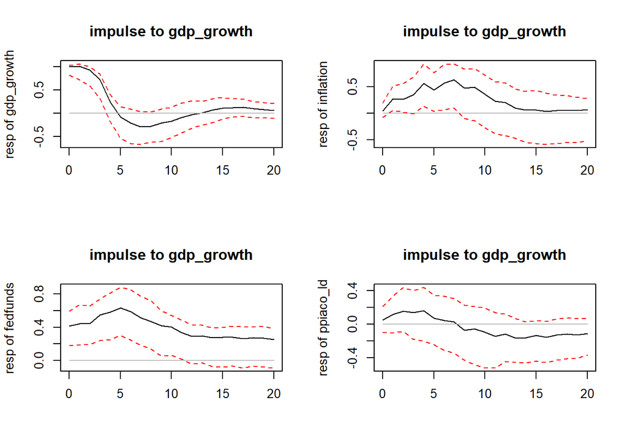

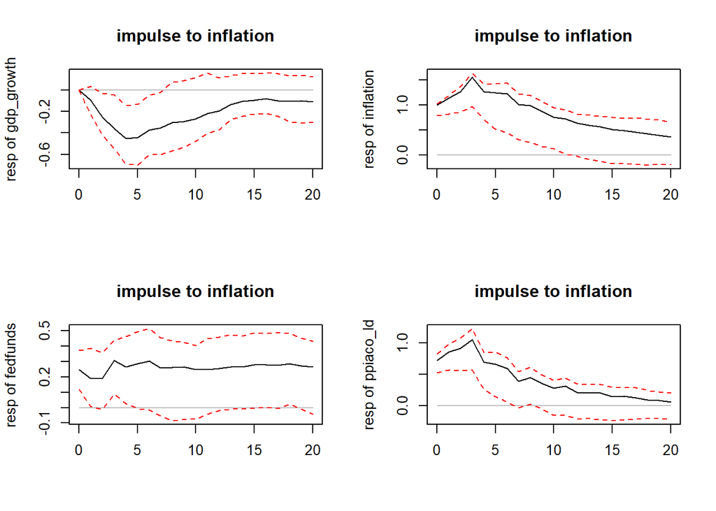

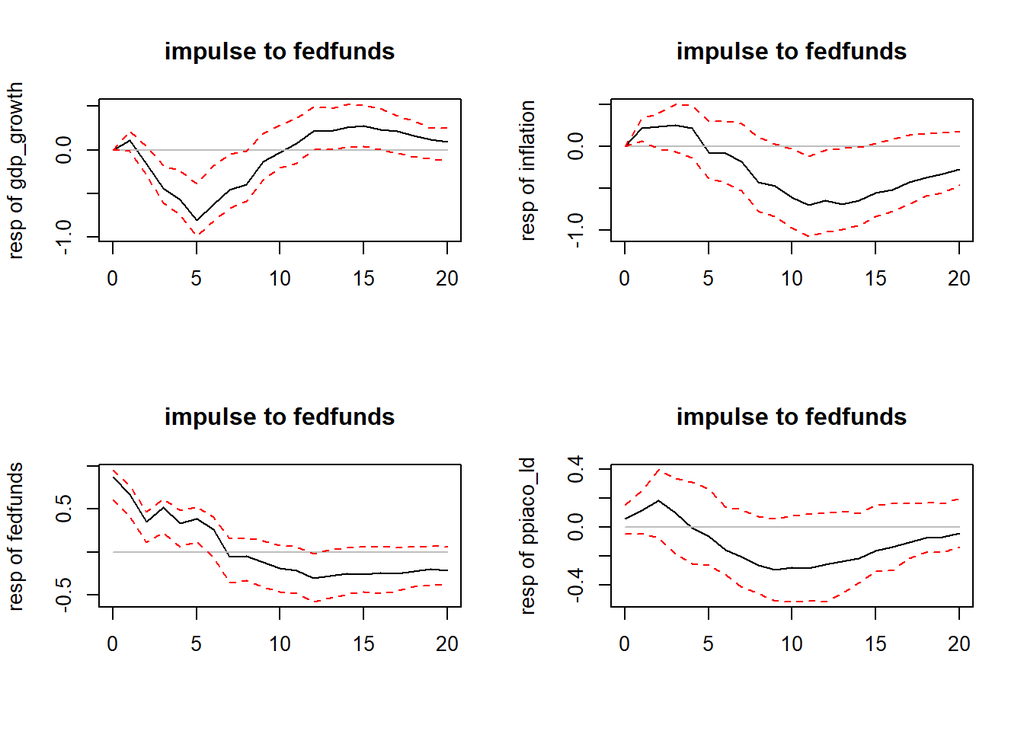

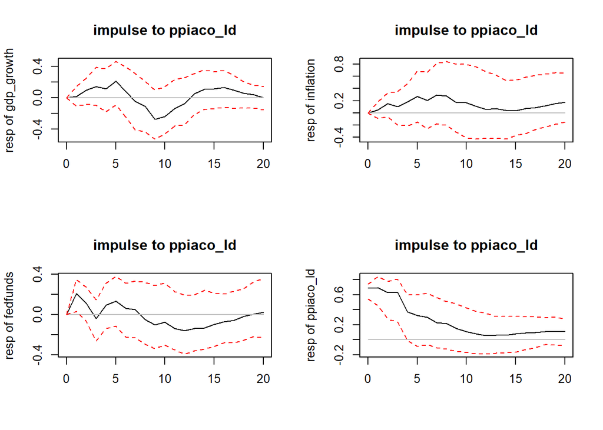

```r
# set seeSD to 1 if want to see results in terms of residual
# standard deviations (default = in terms of level responses)

seeSD = 1
cn <- colnames(vardata1)

par(mfrow = c(2,2))
divv = rep(1,length(cn))
if (seeSD == 1){divv = (diag(summary(var1)$covres))^(1/2)}

for (ii in 1:length(cn)){
  lev <- var1irf$irf[[ii]]
  upp <- var1irf$Upper[[ii]]
  low <- var1irf$Lower[[ii]]

  for (jj in 1:length(cn)){
    ylimm = c(min(low[,jj],lev[,jj],0),
              max(upp[,jj],lev[,jj],0))/divv[jj]
    plot(0:nAhead,lev[,jj]/divv[jj],type = "l",ylim = ylimm, ann=F)
    title(ylab = paste("resp of", cn[jj]),
          main=paste("impulse to",  cn[ii]))
    lines(0:nAhead,(0:nAhead)*0, col="gray")
    lines(0:nAhead,low[,jj]/divv[jj],lty = 2, col="red")
    lines(0:nAhead,upp[,jj]/divv[jj],lty = 2, col="red")
  }
}
```

```r
# note:
# what happens, if ortho = F ? - no decomposition at all,
# shocking each variable irrespectively to the covariance
# matrix (as if there was identify covariance matrix)
# => responses in period=1 are equal to "1" for shocked
#    variables and 0 otherwise
```

##### Custom plots of FEVDs

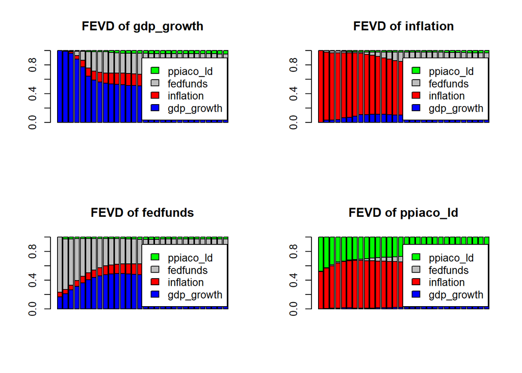

```r
par(mfrow =c(2,2))
for (ii in 1:length(cn)){
  barplot(t(fevd(var1,n.ahead = 30)[[ii]]),
          col=c("blue","red","gray","green"),
          legend = cn, ann=F)
  title(main=paste("FEVD of",  cn[ii]))

}
```

```r
# for gdp growth, only gdp growth shock has contemporary effect
#  => first column contains gdpGap only
# for cpi, cpi and gdpGap shocks are present in the first
# perod etc.
```

##### Custom historical decomposition

```r
# install.packages("reshape")
library(reshape)
library(data.table)
xx <- as.data.frame(var1_cholesky_hd$hidec)
#dfhd = xx
dfhd = xx[,c("V1","Cumulative effect of  gdp_growth shock on  gdp_growth", "Cumulative effect of  inflation shock on  gdp_growth", "Cumulative effect of  fedfunds shock on  gdp_growth", "Cumulative effect of  ppiaco_ld shock on  gdp_growth")]
dfhd.mlt <- melt(dfhd, id = "V1") # melting the data frame #
```

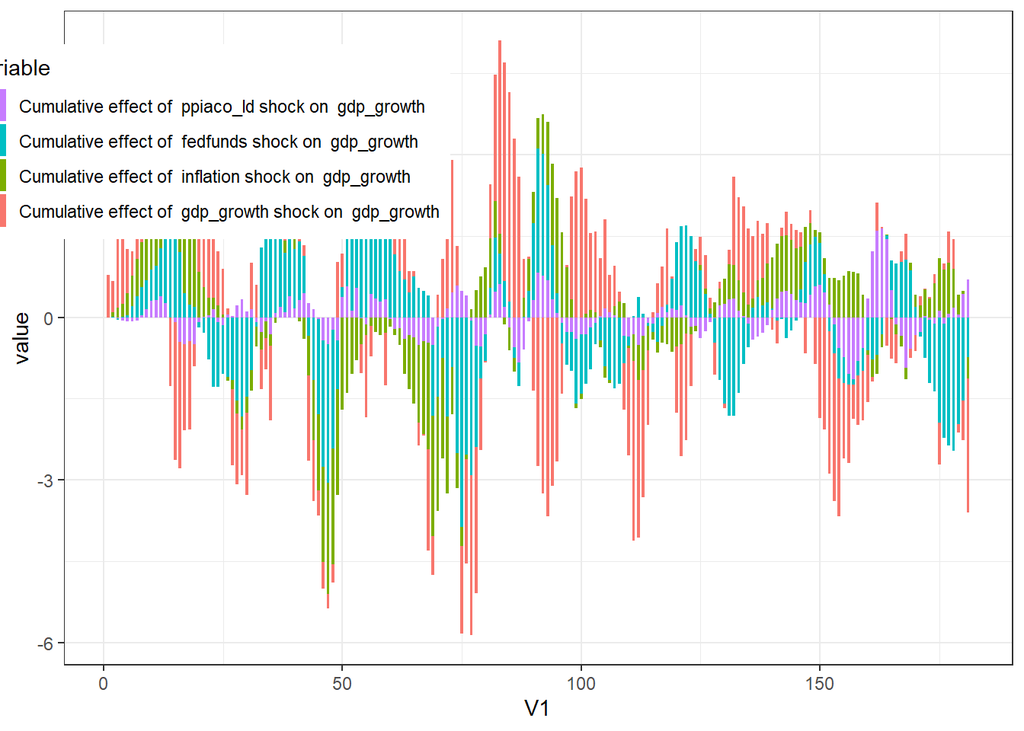

```r
options(repr.plot.height = 8, repr.plot.width = 20)
ggplot(dfhd.mlt, aes(x = V1, y = value, fill = variable)) +
  geom_bar(stat = "identity", width = 0.6) +
  guides(fill = guide_legend(reverse = TRUE))
```

#### II. VAR model: Volcker-Greenspan era

```r
data_7908 <- data_var["1978-01-01/2008-07-01"]
vardata2 <- data_7908[,c("gdp_growth", "inflation", "fedfunds", "ppiaco_ld")]
var2.select <- VARselect(vardata2, lag.max=6, type ="const")
var2.select$selection
```

```
## AIC(n)  HQ(n)  SC(n) FPE(n)
##      6      3      2      6
```

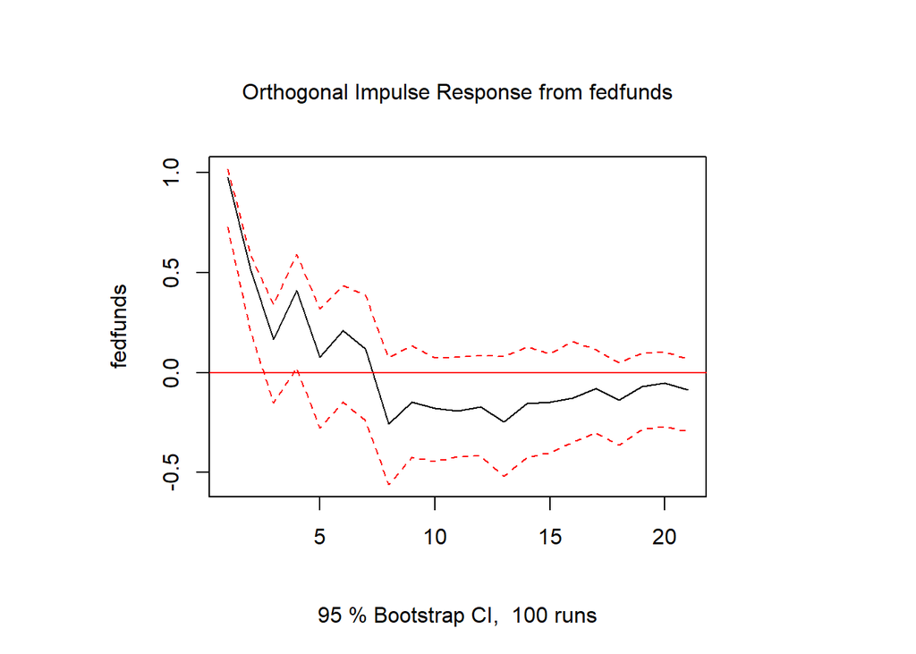

```r
var2 <- VAR(vardata2, p=6, type = "const")
#summary(var2)
#plot(var2)
#plot(irf(var2, n.ahead = 20))
plot(irf(var2,impulse = "fedfunds", response = "fedfunds", n.ahead = 20))
```

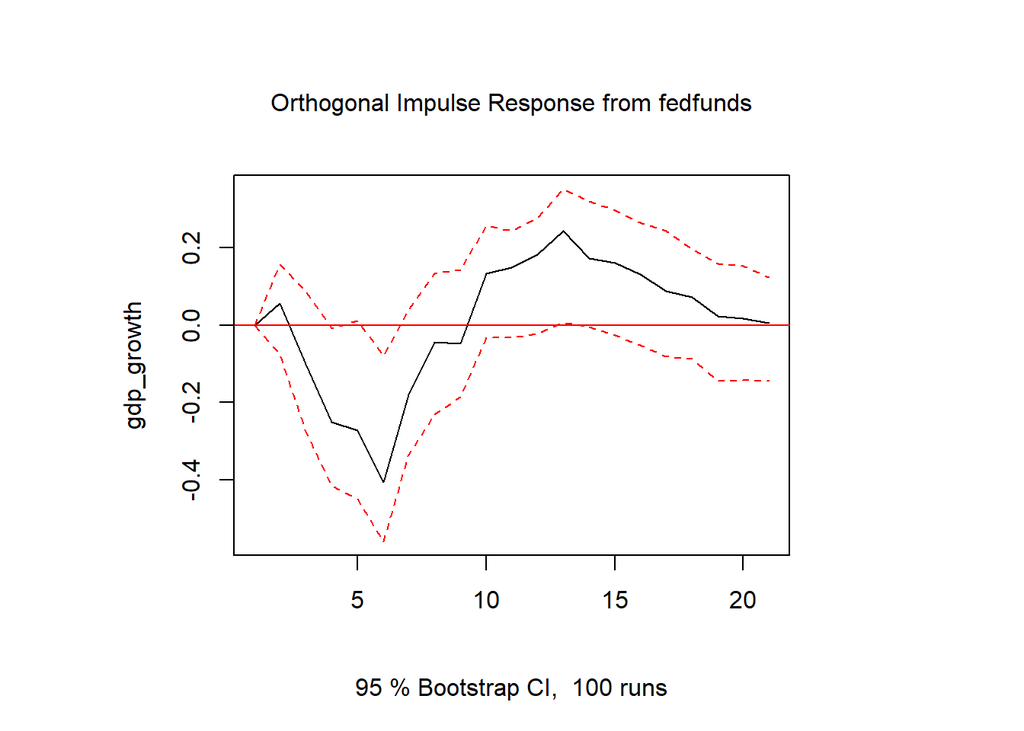

```r
plot(irf(var2,impulse = "fedfunds", response = "gdp_growth", n.ahead = 20))
```

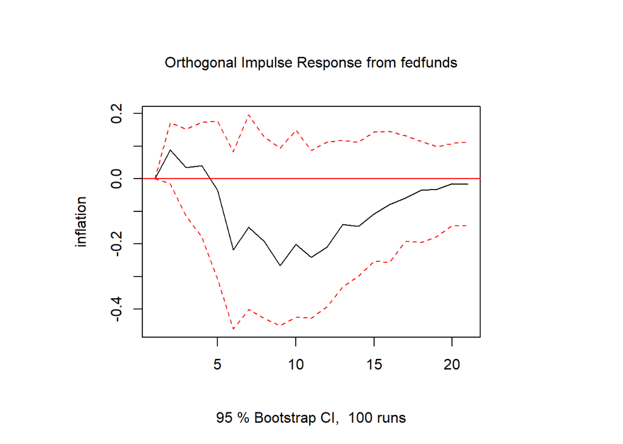

```r
plot(irf(var2,impulse = "fedfunds", response = "inflation", n.ahead = 20))
```

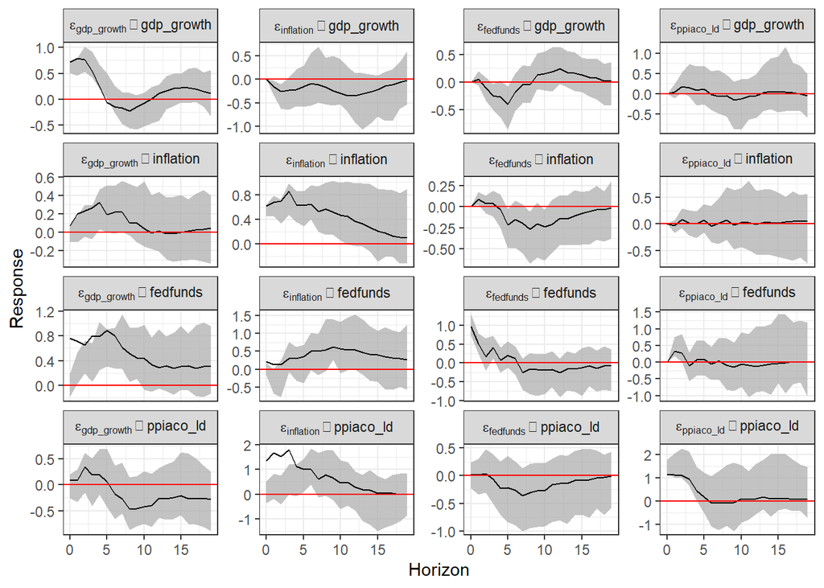

```r
var2_cholesky <- id.chol(var2) #performs Cholesky identification
var2_bootirf <- wild.boot(var2_cholesky, design = "fixed", distr = "gaussian", n.ahead = 20, nboot = 100)
plot(var2_bootirf, lowerq = 0.05, upperq = 0.95)
```

#### III. VAR model: Volcker-Greenspan + Zero-lower bound period

For the period after the Great Recession, characterized by the zero-lower bound of interest rates and unconventional monetary policies, we replace the fed rate by the so-called shadow rate.

```
## Defaulting to continuous.
```

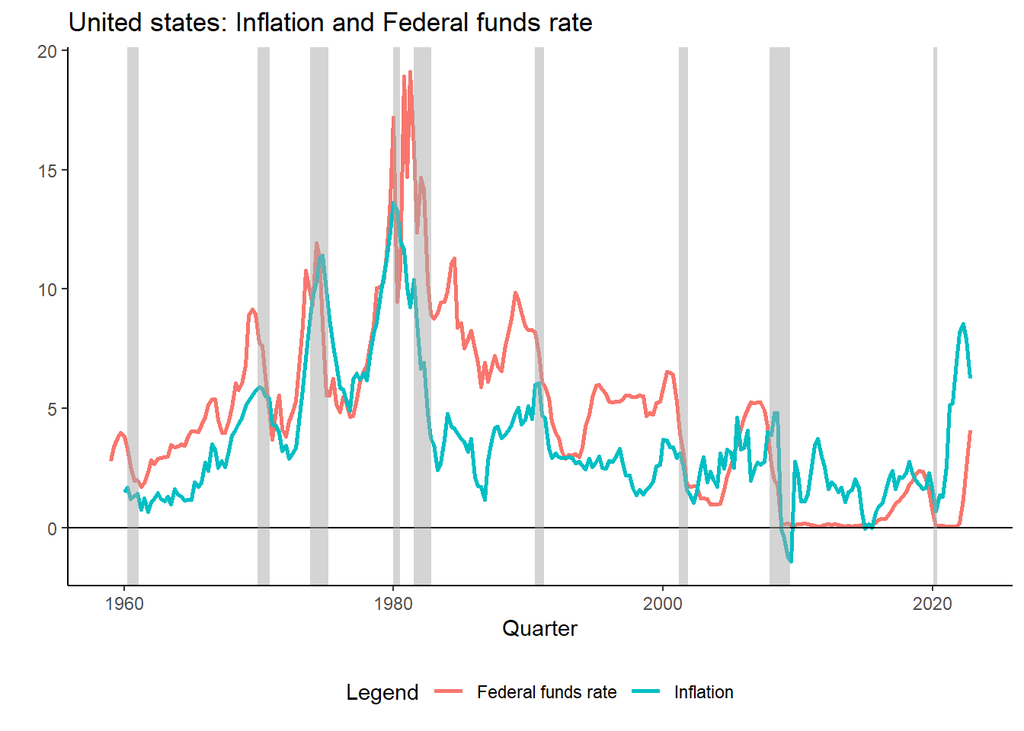

```r
#Shadow rate - construction from the federal funds rate and the shadow rate from Cynthia Wu's website
data_shadow6008 <- data_var$FEDFUNDS["1959-01-01/2008-12-31"]
data_shadow6008 <- ts_first_of_period(data_shadow6008)
data_shadow0915 <- ts(c(0.75,0.02,-0.41,-0.15,-0.48,-0.54,-0.80,-0.88,-0.99,-1.12,-1.40,-1.47,-1.27,-1.11,-1.36,-1.43,-1.44,-0.97,-1.80,-2.13,-2.62,-2.89,-2.81,-2.42,-1.81,-1.38,-0.74,-0.004),start=c(2009,01), frequency = 4)
data_shadow0915 <- ts_xts(data_shadow0915)
data_shadow1620 <- data_var$FEDFUNDS["2016-01-01/2020-03-01"]
data_shadow2021 <- ts(c(0.40,0.08,-0.29,-1.56,-1.83,-1.81,-1.15), start = c(2020,02), frequency = 4)
data_shadow2021 <- ts_xts(data_shadow2021)
data_shadow22end <- data_var$FEDFUNDS["2022-01-01/"]
data_var$shadowrate <- rbind(data_shadow6008,data_shadow0915,data_shadow1620,data_shadow2021,data_shadow22end)
#autoplot(data_var$shadowrate)

recessions.df = read.table(textConnection(
  "Peak, Trough
      1960-04-01, 1961-02-01
      1969-12-01, 1970-11-01
      1973-11-01, 1975-03-01
      1980-01-01, 1980-07-01
      1981-07-01, 1982-11-01
      1990-07-01, 1991-03-01
      2001-03-01, 2001-11-01
      2007-12-01, 2009-06-01
      2020-02-01, 2020-05-01"), sep=',',
  colClasses=c('Date', 'Date'), header=TRUE)

ggplot() +
  geom_line(data = data_var$fedfunds, aes(x = Index, y = data_var$fedfunds, color = "Federal funds rate"), lwd = 1) +
  geom_line(data = data_var$inflation, aes(x = Index, y = data_var$inflation, color = "Inflation"), lwd = 1) +
  geom_hline(yintercept=0)+
  geom_rect(data=recessions.df, inherit.aes=F, aes(xmin=Peak, xmax=Trough, ymin=-Inf, ymax=+Inf), fill='darkgray', alpha=0.5) +
  theme_classic() +
  labs(title = "United states: Inflation and Federal funds rate", x = "Quarter", y = "") +
  labs(color="Legend") +
  theme(legend.position="bottom")
```

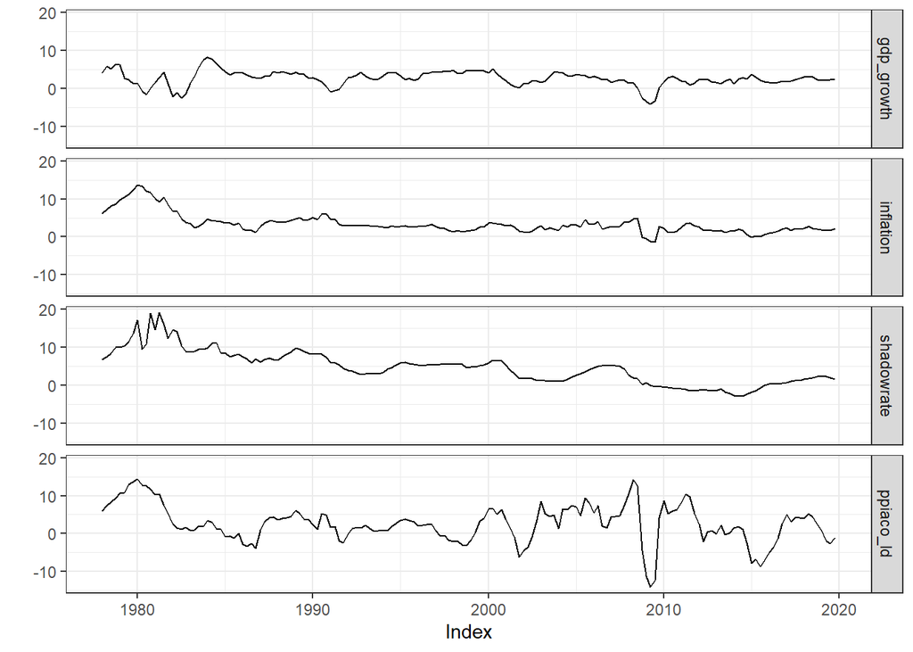

```r
data_7919 <- data_var["1978-01-01/2019-12-01"]
vardata3 <- data_7919[,c("gdp_growth", "inflation", "shadowrate", "ppiaco_ld")]
autoplot(vardata3)
```

```r
var3.select <- VARselect(vardata3, lag.max=6, type ="const")
var3.select$selection
```

```
## AIC(n)  HQ(n)  SC(n) FPE(n)
##      6      6      2      6
```

```r
var3 <- VAR(vardata3, p=6, type = "const")
summary(var3)
```

```
##
## VAR Estimation Results:
## =========================
## Endogenous variables: gdp_growth, inflation, shadowrate, ppiaco_ld
## Deterministic variables: const
## Sample size: 162
## Log Likelihood: -763.843
## Roots of the characteristic polynomial:
## 0.9638 0.8804 0.8804 0.8591 0.8591 0.8508 0.8508 0.8401 0.8401 0.8201 0.8201 0.799 0.799 0.7973 0.7973 0.7898 0.7748 0.7748 0.7326 0.7326 0.732 0.732  0.46 0.2427
## Call:
## VAR(y = vardata3, p = 6, type = "const")
##
##
## Estimation results for equation gdp_growth:
## ===========================================
## gdp_growth = gdp_growth.l1 + inflation.l1 + shadowrate.l1 + ppiaco_ld.l1 + gdp_growth.l2 + inflation.l2 + shadowrate.l2 + ppiaco_ld.l2 + gdp_growth.l3 + inflation.l3 + shadowrate.l3 + ppiaco_ld.l3 + gdp_growth.l4 + inflation.l4 + shadowrate.l4 + ppiaco_ld.l4 + gdp_growth.l5 + inflation.l5 + shado…
##
##               Estimate Std. Error t value Pr(>|t|)
## gdp_growth.l1  1.16352    0.09215  12.627   <2e-16 ***
## inflation.l1  -0.41914    0.16168  -2.592   0.0106 *
## shadowrate.l1  0.07076    0.05895   1.200   0.2321
## ppiaco_ld.l1   0.09714    0.04836   2.009   0.0465 *
## gdp_growth.l2 -0.06915    0.12907  -0.536   0.5930
## inflation.l2   0.20937    0.22694   0.923   0.3579
## shadowrate.l2 -0.09763    0.06799  -1.436   0.1533
## ppiaco_ld.l2  -0.04721    0.07224  -0.653   0.5145
## gdp_growth.l3 -0.26011    0.12253  -2.123   0.0356 *
## inflation.l3   0.50764    0.20402   2.488   0.0140 *
## shadowrate.l3 -0.03892    0.07007  -0.555   0.5796
## ppiaco_ld.l3  -0.14785    0.07078  -2.089   0.0386 *
## gdp_growth.l4 -0.17678    0.11585  -1.526   0.1293
## inflation.l4  -0.31270    0.19894  -1.572   0.1183
## shadowrate.l4  0.03416    0.07189   0.475   0.6354
## ppiaco_ld.l4   0.07645    0.07099   1.077   0.2834
## gdp_growth.l5  0.28808    0.11917   2.417   0.0169 *
## inflation.l5  -0.17621    0.21346  -0.825   0.4105
## shadowrate.l5 -0.07194    0.07548  -0.953   0.3422
## ppiaco_ld.l5   0.06634    0.07086   0.936   0.3508
## gdp_growth.l6 -0.05114    0.07936  -0.644   0.5204
## inflation.l6   0.18167    0.15336   1.185   0.2382
```

[output cut: 128 more lines]

```
##
##
## Covariance matrix of residuals:
##            gdp_growth inflation shadowrate ppiaco_ld
## gdp_growth     0.5149    0.1476     0.3914    0.4233
## inflation      0.1476    0.4822     0.1682    1.3243
## shadowrate     0.3914    0.1682     1.2508    0.3915
## ppiaco_ld      0.4233    1.3243     0.3915    4.9813
##
## Correlation matrix of residuals:
##            gdp_growth inflation shadowrate ppiaco_ld
## gdp_growth     1.0000    0.2962     0.4878    0.2643
## inflation      0.2962    1.0000     0.2165    0.8545
## shadowrate     0.4878    0.2165     1.0000    0.1568
## ppiaco_ld      0.2643    0.8545     0.1568    1.0000
```

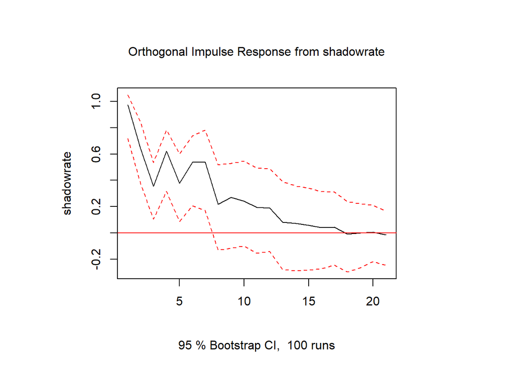

```r
#plot(var3)
#plot(irf(var3, n.ahead = 20))
plot(irf(var3,impulse = "shadowrate", response = "shadowrate", n.ahead = 20))
```

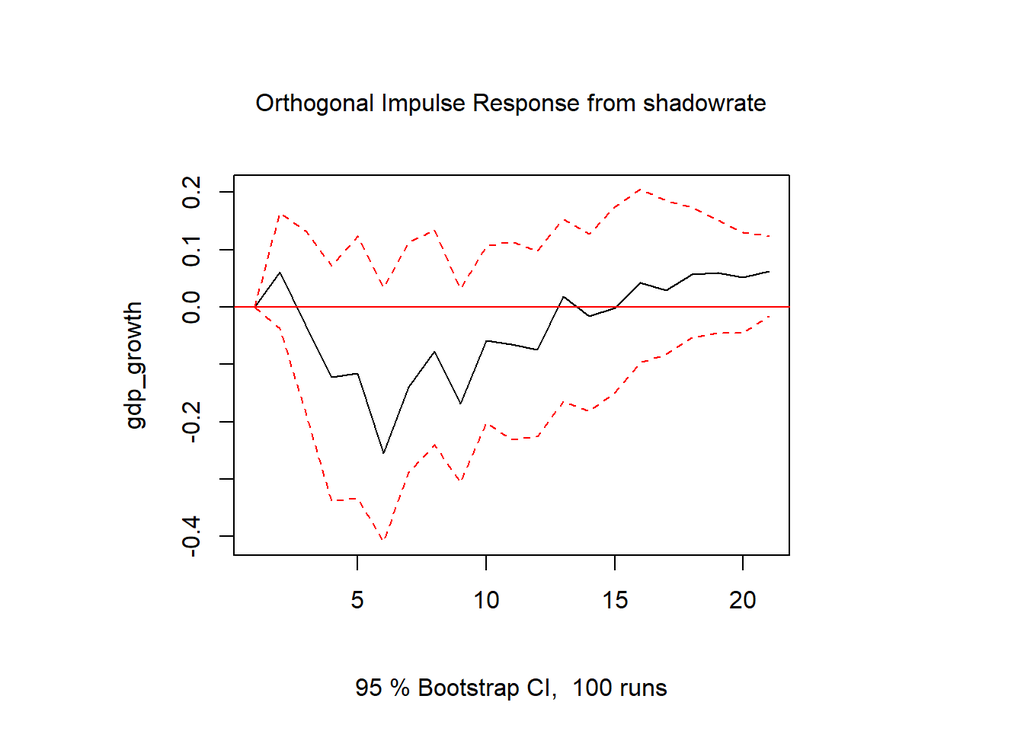

```r
plot(irf(var3,impulse = "shadowrate", response = "gdp_growth", n.ahead = 20))
```

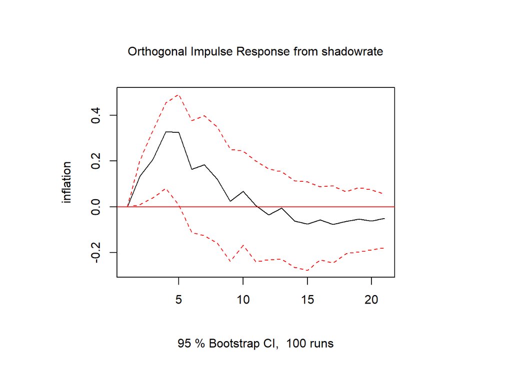

```r
plot(irf(var3,impulse = "shadowrate", response = "inflation", n.ahead = 20))
```

```r
#MP shock not identified
```

#### IV. VAR model: Commodity prices ordered first

```r
vardata4 <- data_7919[,c("ppiaco_ld", "gdp_growth", "inflation", "shadowrate")]
var4.select <- VARselect(vardata4, lag.max=6, type ="const")
var4.select$selection
```

```
## AIC(n)  HQ(n)  SC(n) FPE(n)
##      6      6      2      6
```

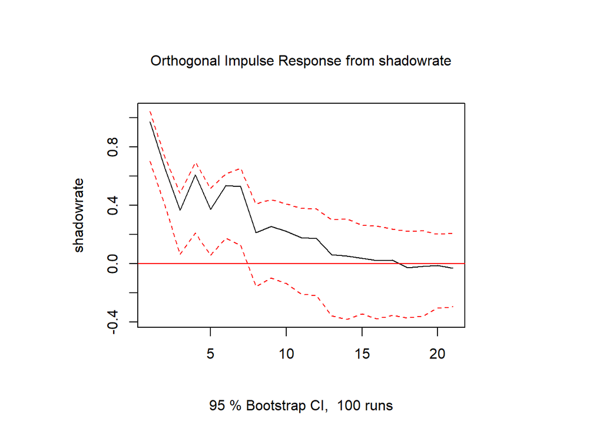

```r
var4 <- VAR(vardata4, p=6, type = "const")
#summary(var4)
#plot(var4)
#plot(irf(var4, n.ahead = 20))
plot(irf(var4,impulse = "shadowrate", response = "shadowrate", n.ahead = 20))
```

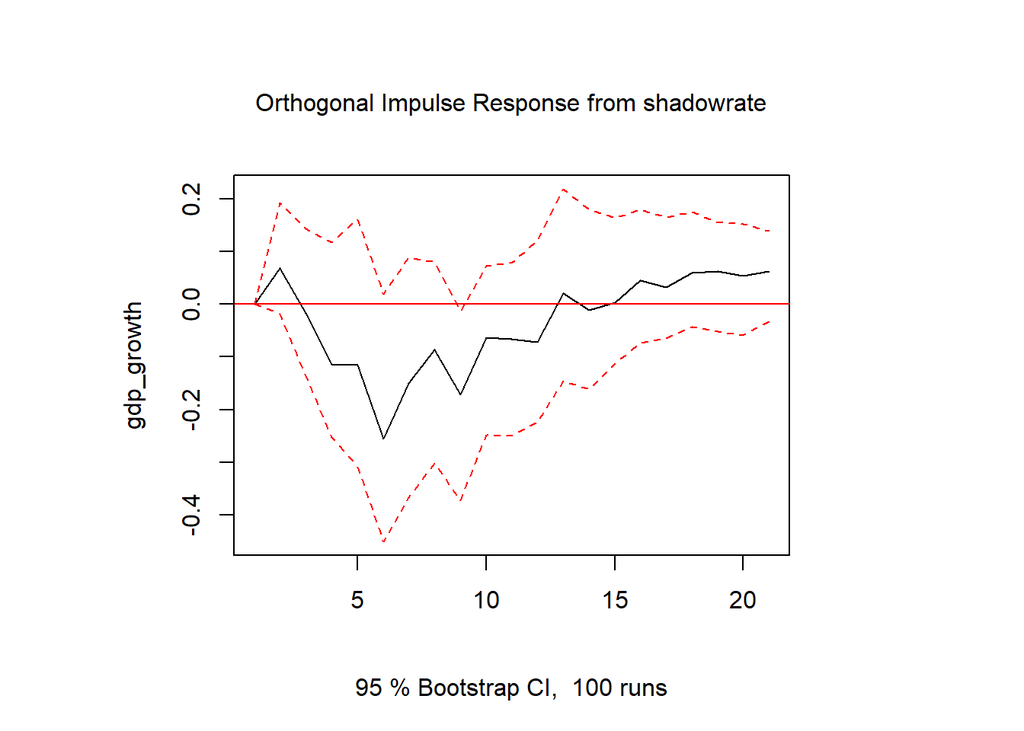

```r
plot(irf(var4,impulse = "shadowrate", response = "gdp_growth", n.ahead = 20))
```

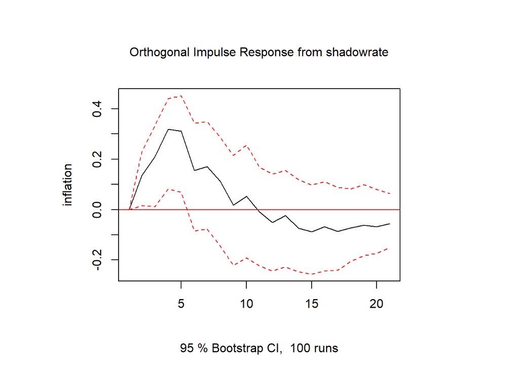

```r
plot(irf(var4,impulse = "shadowrate", response = "inflation", n.ahead = 20))
```

```r
#no improvement, some price puzzle remains
```

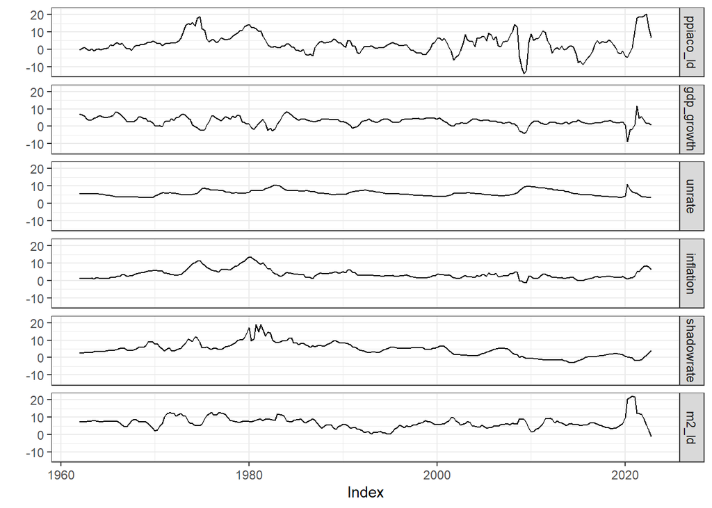

```r
data_6222 <- data_var["1962-01-01/2022-12-01"]
vardata5 <- data_6222[,c("ppiaco_ld", "gdp_growth", "unrate", "inflation", "shadowrate", "m2_ld")]
autoplot(vardata5)
```

```r
var5.select <- VARselect(vardata5, lag.max=6, type ="const")
var5.select$selection
```

```
## AIC(n)  HQ(n)  SC(n) FPE(n)
##      6      5      1      6
```

```r
var5 <- VAR(vardata5, p=6, type = "const")
summary(var5)
```

```
##
## VAR Estimation Results:
## =========================
## Endogenous variables: ppiaco_ld, gdp_growth, unrate, inflation, shadowrate, m2_ld
## Deterministic variables: const
## Sample size: 238
## Log Likelihood: -1599.534
## Roots of the characteristic polynomial:
## 0.9763 0.9304 0.9304 0.8834 0.8834 0.8832 0.8792 0.8792 0.8774 0.8774 0.8759 0.8759 0.8584 0.8584 0.8487 0.8487 0.8151 0.8151 0.7965 0.7965 0.7895 0.7895 0.7587 0.7587 0.7502 0.7502 0.7411 0.7411 0.7176 0.7176 0.6936 0.6936 0.6688 0.6688 0.2693 0.2178
## Call:
## VAR(y = vardata5, p = 6, type = "const")
##
##
## Estimation results for equation ppiaco_ld:
## ==========================================
## ppiaco_ld = ppiaco_ld.l1 + gdp_growth.l1 + unrate.l1 + inflation.l1 + shadowrate.l1 + m2_ld.l1 + ppiaco_ld.l2 + gdp_growth.l2 + unrate.l2 + inflation.l2 + shadowrate.l2 + m2_ld.l2 + ppiaco_ld.l3 + gdp_growth.l3 + unrate.l3 + inflation.l3 + shadowrate.l3 + m2_ld.l3 + ppiaco_ld.l4 + gdp_growth.l4 +…
##
##                Estimate Std. Error t value Pr(>|t|)
## ppiaco_ld.l1   1.172662   0.115361  10.165  < 2e-16 ***
## gdp_growth.l1  0.047122   0.213949   0.220  0.82590
## unrate.l1     -0.156704   0.427991  -0.366  0.71465
## inflation.l1   0.231067   0.373135   0.619  0.53645
## shadowrate.l1  0.178157   0.136632   1.304  0.19375
## m2_ld.l1       0.282267   0.153729   1.836  0.06781 .
## ppiaco_ld.l2  -0.513097   0.157556  -3.257  0.00132 **
## gdp_growth.l2 -0.105574   0.237450  -0.445  0.65708
## unrate.l2     -0.040019   0.500467  -0.080  0.93635
## inflation.l2   0.206795   0.501935   0.412  0.68078
## shadowrate.l2  0.207447   0.177104   1.171  0.24285
## m2_ld.l2      -0.207777   0.243192  -0.854  0.39391
## ppiaco_ld.l3   0.140277   0.150742   0.931  0.35319
## gdp_growth.l3  0.065787   0.182838   0.360  0.71937
## unrate.l3      1.277759   0.408028   3.132  0.00200 **
## inflation.l3   0.143847   0.449369   0.320  0.74922
## shadowrate.l3  0.002429   0.182501   0.013  0.98939
## m2_ld.l3      -0.131052   0.220291  -0.595  0.55258
## ppiaco_ld.l4  -0.261128   0.149399  -1.748  0.08202 .
## gdp_growth.l4  0.243559   0.181460   1.342  0.18104
## unrate.l4      0.114713   0.421458   0.272  0.78576
## inflation.l4  -1.128839   0.437359  -2.581  0.01056 *
```

[output cut: 282 more lines]

```
## ppiaco_ld     4.3043     0.4005 -0.16361   1.10983     0.3779 -0.4776
## gdp_growth    0.4005     1.1590 -0.48325   0.12450     0.3413 -0.5726
## unrate       -0.1636    -0.4832  0.32330  -0.04979    -0.1653  0.3544
## inflation     1.1098     0.1245 -0.04979   0.44055     0.1398 -0.1700
## shadowrate    0.3779     0.3413 -0.16528   0.13979     1.1688 -0.2371
## m2_ld        -0.4776    -0.5726  0.35444  -0.17004    -0.2371  1.2337
##
## Correlation matrix of residuals:
##            ppiaco_ld gdp_growth  unrate inflation shadowrate   m2_ld
## ppiaco_ld     1.0000     0.1793 -0.1387    0.8059     0.1685 -0.2073
## gdp_growth    0.1793     1.0000 -0.7895    0.1742     0.2933 -0.4789
## unrate       -0.1387    -0.7895  1.0000   -0.1319    -0.2689  0.5612
## inflation     0.8059     0.1742 -0.1319    1.0000     0.1948 -0.2306
## shadowrate    0.1685     0.2933 -0.2689    0.1948     1.0000 -0.1974
## m2_ld        -0.2073    -0.4789  0.5612   -0.2306    -0.1974  1.0000
```

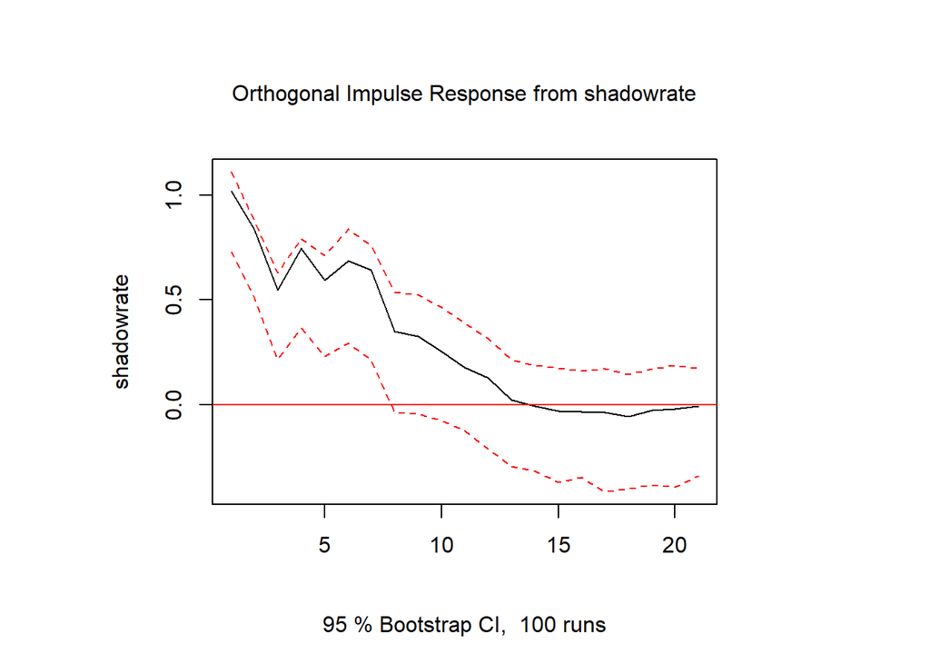

```r
#plot(var5)
#plot(irf(var5, n.ahead = 20))
plot(irf(var5,impulse = "shadowrate", response = "shadowrate", n.ahead = 20))
```

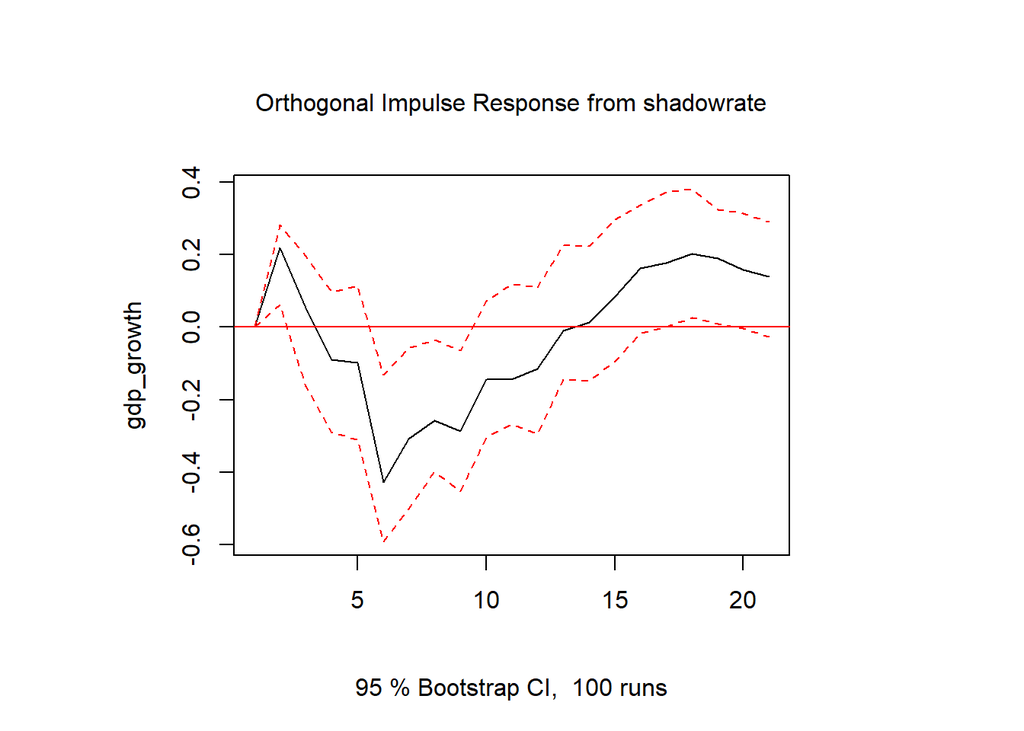

```r
plot(irf(var5,impulse = "shadowrate", response = "gdp_growth", n.ahead = 20))
```

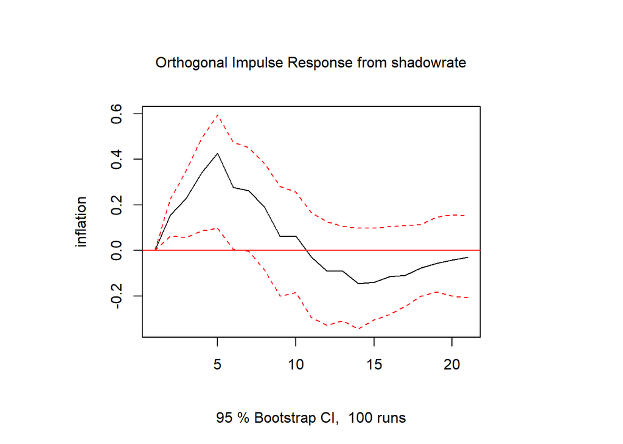

```r
plot(irf(var5,impulse = "shadowrate", response = "inflation", n.ahead = 20))
```

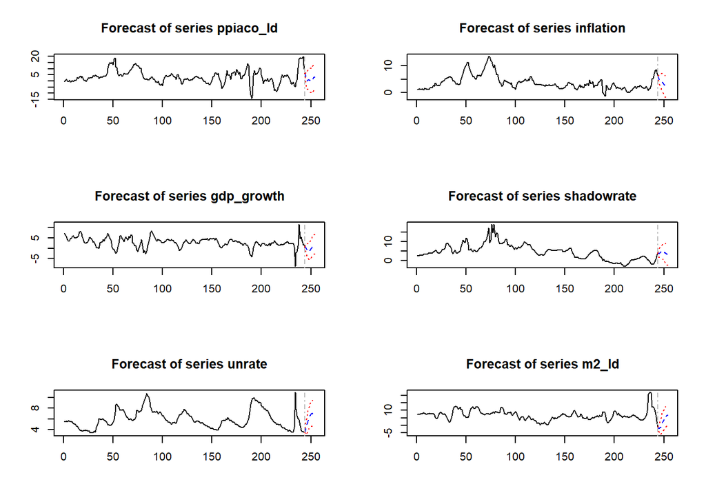

```r
plot(predict(var5))
```

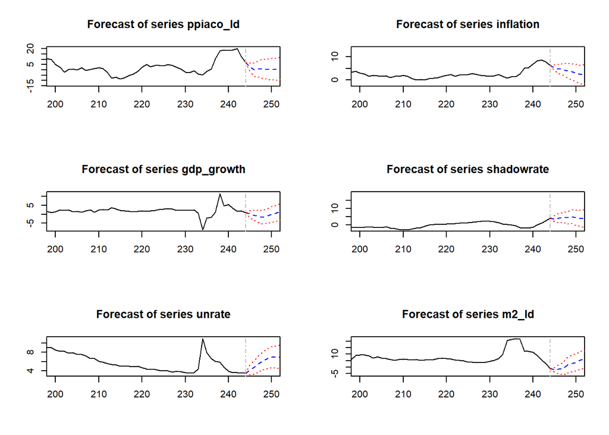

```r
plot(predict(var5),xlim=c(200,250))
```

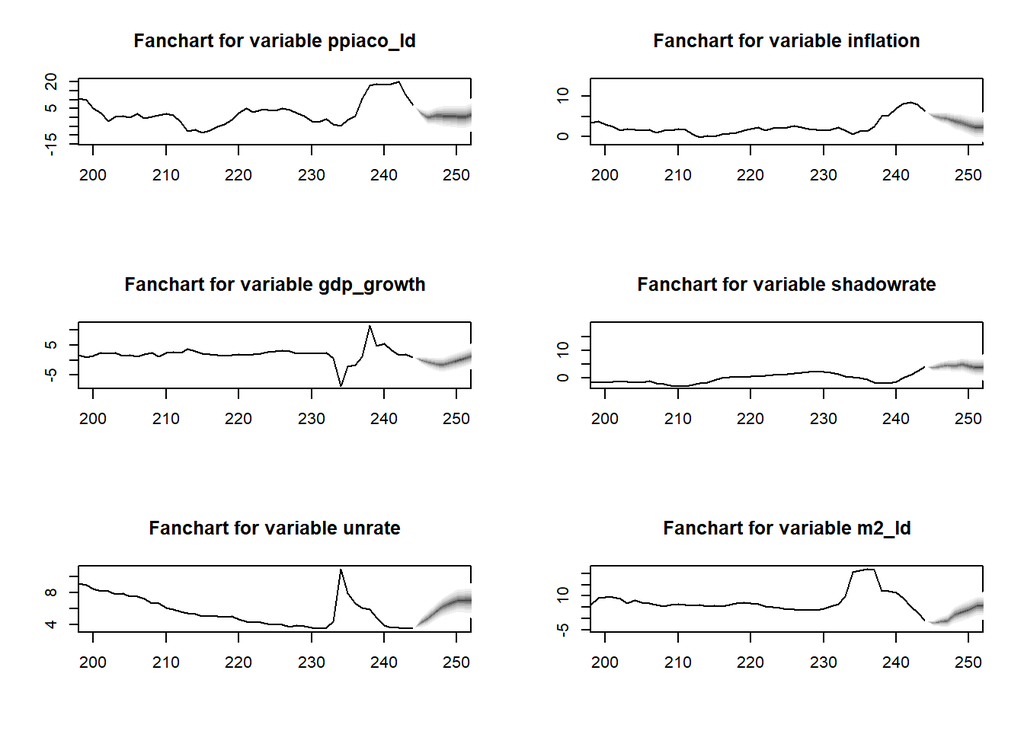

```r
fanchart(predict(var5),xlim=c(200,250))
```

```r
predict(var5)
```

```
## $ppiaco_ld
##             fcst     lower     upper        CI
##  [1,]  2.4752397 -1.591083  6.541562  4.066323
##  [2,] -0.1022067 -6.569405  6.364992  6.467198
##  [3,]  0.9394771 -6.994899  8.873853  7.934376
##  [4,]  0.8160869 -8.264392  9.896566  9.080479
##  [5,]  0.5656607 -9.028226 10.159547  9.593887
##  [6,]  0.5851835 -9.407718 10.578086  9.992902
##  [7,]  0.2486147 -9.985955 10.483184 10.234570
##  [8,]  1.5269943 -8.921605 11.975593 10.448599
##  [9,]  2.8757553 -7.807687 13.559198 10.683442
## [10,]  3.5031067 -7.355712 14.361925 10.858818
##
## $gdp_growth
##             fcst     lower    upper       CI
```

[output cut: 62 more lines]